# section4

ariswa

3/28/2020

## Case Study: Trends in World Health and Economics

**[Video](https://courses.edx.org/courses/course-v1:HarvardX+PH125.2x+1T2020/courseware/ad1143653dd340e98114aa5d201f76d5/51b33a53fbb6471e9044703e2822174b/?child=first)**  
RAFAEL IRIZARRY: In this section, we will demonstrate how relatively simple ggplot and dplyr code can create insightful and aesthetically pleasing plots that help us better understand trends in world health and economics.  
We will use many of the techniques we have learned about data visualization, exploratory data analysis, and summarization.  
We later augment the code somewhat to perfect the plots, and describe some general principles to guide data visualization. We’re going to be using data from Gapminder. Hans Rosling was the co-founder of the Gapminder Foundation, an organization dedicated to educating the public by using data to dispel common myths about the so-called developing world.  
The organization uses data to show how actual trends in health and economics contradict the narratives that emanate from sensationalist media coverage of catastrophes, tragedies, and other unfortunate events. As stated in the Gapminder Foundation’s website, “Journalists and lobbyists tell dramatic stories. That’s their job. They tell stories about extraordinary events and unusual people. The piles of dramatic stories pile up in people’s minds into an overdramatic worldview and strong negative stress feelings. The world is getting worse. It’s we versus them. Other people are strange. The population just keeps growing. And nobody cares.” Hans Rosling conveyed actual data-based trends, in a dramatic way of his own, using effective data visualization. This section is based on these talks that exemplify this approach to education. “New Insights on Poverty” and “The Best Stats You’ve Ever Seen” are the title of these talks. Specifically, in this section, we set out to answer the following two questions. First, is it a fair characterization of today’s world to say that it is divided into a Western rich nations, and the developing world in Africa, Asia, and Latin America? Second, has income inequality across countries worsened during the last 40 years? We’re going to use data and our code to answer these questions.  
This video corresponds to the [textbook section introducing the case study on new insights in poverty](https://rafalab.github.io/dsbook/gapminder.html#case-study-new-insights-on-poverty).

### More about Gapminder

The original Gapminder TED talks are available and we encourage you to watch them.

- [The Best Stats You’ve Ever Seen](https://www.ted.com/talks/hans_rosling_shows_the_best_stats_you_ve_ever_seen?language=en)
- [New Insights on Poverty](https://www.ted.com/talks/hans_rosling_reveals_new_insights_on_poverty?language=en)

You can also find more information and raw data (in addition to what we analyze in class) at https://www.gapminder.org/.  
Key points

- Data visualization can be used to dispel common myths and educate the public and contradict sensationalist or outdated claims and stories.
- We will use real data to answer the following questions about world health and economics:
- Is it still fair to consider the world as divided into the West and the developing world?
- Has income inequality across countries worsened over the last 40 years?

## Gapminder Dataset

RAFAEL IRIZARRY: To learn about world health and economics, we will be using the Gapminder data set provided in the dslabs library. This dataset was put together for you, and it was created using a number of spreadsheets available from the Gapminder Foundation.

You can access the table using this code. We load the dslabs package, then we type data gapminder, and we can see that the data includes country, year, and several health outcomes and economics outcomes.

As done in the New Insights on Poverty video, we start by testing our knowledge regarding differences in child mortality across different countries. To get us started, we’re going to take a quiz created by Hans Rosling in his video New Insights on Poverty, and we’re going to start by testing our knowledge regarding differences in child mortality across different countries.

So here’s a quiz. For each of the pairs of countries here, which country do you think had the highest child mortality in 2015? And also, which pairs do you think are most similar? When answering these questions without data, the non-European countries are typically picked as having higher mortality rates, Sri Lanka over Turkey, South Korea over Poland, and Malaysia over Russia. It is also common to assume that countries considered to be part of the developing world, Pakistan, Vietnam, Thailand, and South Africa, have similarly high mortality rates.

Now let’s answer these questions with data. For example, for this first comparison, we can write this simple dplyr code to see that Turkey has a higher mortality rate than Sri Lanka. We can use the same code to answer each of the five questions, and we see that Sri Lanka has a lower mortality rate than Turkey, South Korea has a lower mortality rate than Poland, Malaysia has a lower mortality rate than Russia, and Pakistan is very different from Vietnam, and South Africa is very different from Thailand.

From here, we see that these comparisons, the European countries have higher rates. We also see that the countries from the developing world can have very different rates. It turns out that most people do worse than if they were just guessing, which implies that we’re more than ignorant, we’re misinformed.

This video corresponds to the [textbook section introducing the case study on new insights on poverty.](https://rafalab.github.io/dsbook/gapminder.html#case-study-new-insights-on-poverty)

**Key points**

- A selection of world health and economics statistics from the Gapminder project can be found in the dslabs package as data(gapminder).
- Most people have misconceptions about world health and economics, which can be addressed by considering real data.

**Codes:**

```r
# compare infant mortality in Sri Lanka and Turkey
gapminder_filter <- gapminder %>%
    filter(year == 2015 & country %in% c("Sri Lanka", "Turkey")) %>%
    select(country, infant_mortality)
gapminder_filter
```

```
##     country infant_mortality
## 1 Sri Lanka              8.4
## 2    Turkey             11.6
```

Tabel perbandingan

| country | infant_mortality |
| --- | --- |
| Sri Lanka | 8.4 |
| Turkey | 11.6 |

## Life Expectancy and Fertility Rates

RAFAEL IRIZARRY: Our misconceptions stem from the preconceived notion that the world is divided into two groups, the Western World, composed of Western Europe and North America, which is characterized by long lifespans and small families versus the developing world, Africa, Asia, and Latin America, characterized by short lifespans and large families.

But does the data support this dichotomous view of the world? The necessary data to answer this question is also available in our gapminder table. Using our newly-learned data visualization skills, we will be able to answer this question.

The first plot we make to see what data have to say about this worldview is a scatterplot of life expectancy versus fertility rates. Fertility rates are defined as the average number of children per woman. We will start by looking at data from about 50 years ago when, perhaps, this worldview was cemented in our minds.

We just type the simple code and we see this plot. Note that most points do, in fact, fall into two distinct categories, one with life expectancies around 70 years and three or less children per family and the other with life expectancies lower than 65 years and with more than five children per family.

Now, to confirm that indeed these countries are from the regions we expect, we can use color to represent continent. So we change the code slightly by adding the color argument, assigning continent to it. Because continent is a character, it will automatically assign color to each continent.

Here’s the plot. So indeed, in 1962, the West versus developing worldview was grounded in some reality, but is this still the case 50 years later? To answer to this question, we’re going to learn about faceting. End of transcript. Skip to the start.

This video corresponds to the [textbook section on Gapminder scatterplots](https://rafalab.github.io/dsbook/gapminder.html#scatterplots).  
**Key points**

- A prevalent worldview is that the world is divided into two groups of countries:
- Western world: high life expectancy, low fertility rate
- Developing world: lower life expectancy, higher fertility rate
- Gapminder data can be used to evaluate the validity of this view.
- A scatterplot of life expectancy versus fertility rate in 1962 suggests that this viewpoint was grounded in reality 50 years ago. Is it still the case today?  
  **Codes**

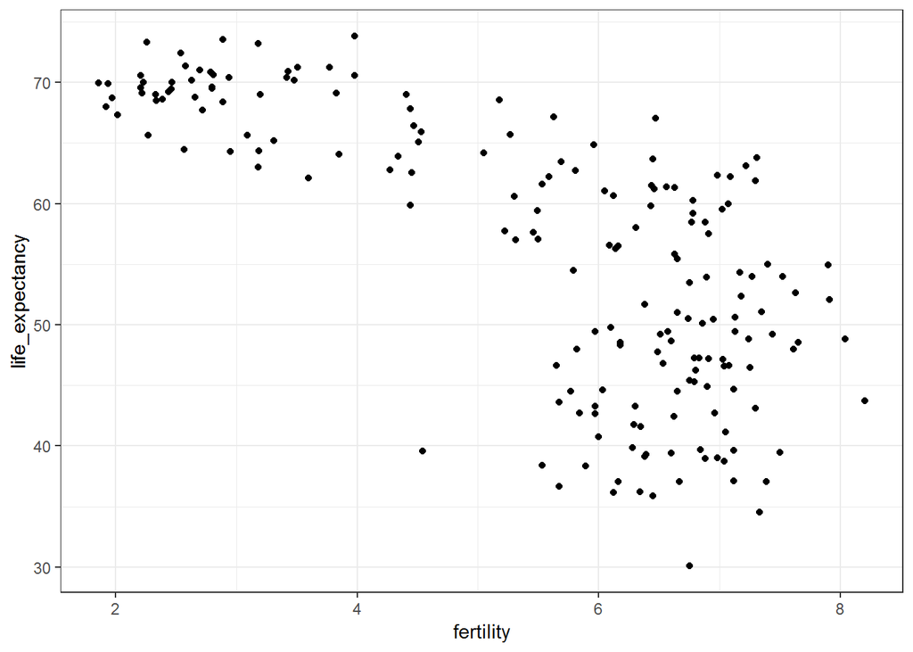

```r
# basic scatterplot of life expectancy versus fertility
ds_theme_set()    # set plot theme
filter(gapminder, year == 1962) %>%
    ggplot(aes(fertility, life_expectancy)) +
    geom_point()
```

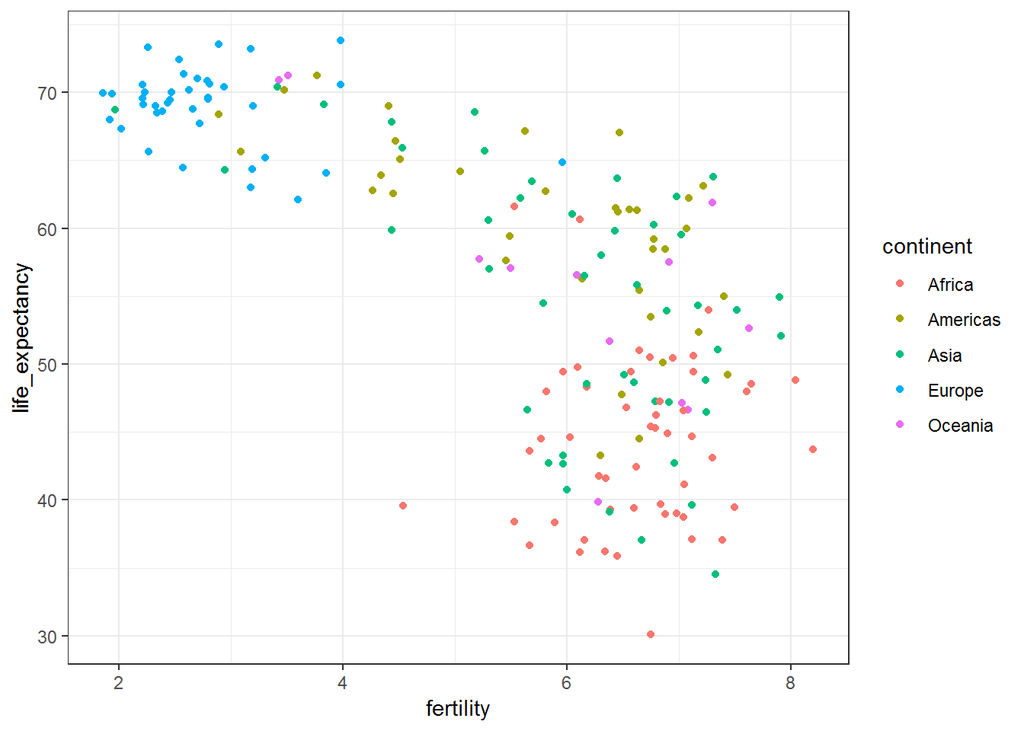

```r
# add color as continent
filter(gapminder, year == 1962) %>%
    ggplot(aes(fertility, life_expectancy, color = continent)) +
    geom_point()
```

## Faceting

RAFAEL IRIZARRY: We could easily plot the 2012 data in the same way we did for 1962. But for comparison, side by side plots are preferable. In ggplot, we can achieve this by faceting variables. We stratify the data by some variable and make the same plot for each strata.

Here we are faceting by the year. To achieve this, we use a function facet_grid. This is added as a layer which automatically separates the plots. The function lets you facet by up to two variables using columns to represent one variable and rows to represent the other. The function expects the rows and column variables separated by a tilde.

Here’s an example. We’re going to facet by continent and year. So continent will be in the rows, and year will be in the columns. Here is the plot. We can see how the data has been stratified. We have 1962 on the left, 2012 on the right, and the 5 continents in each row.

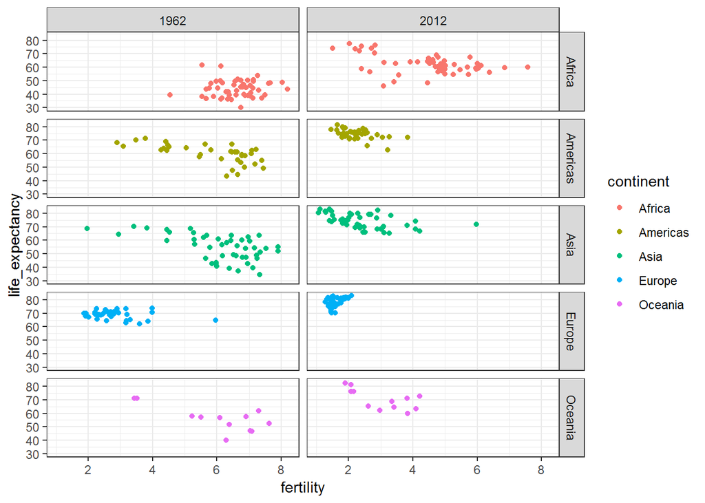

```r
filter(gapminder, year %in% c("1962","2012")) %>%
  ggplot(aes(fertility, life_expectancy, col = continent)) +
  geom_point() +
  facet_grid(continent ~ year)
```

However, this is just an example and more than what we want, which is simply to compare in 1962 and 2012. In this case, there’s just one variable. So what we do is we use the dot to let the facet function know that we’re not using two variables but just one. The code looks like this.

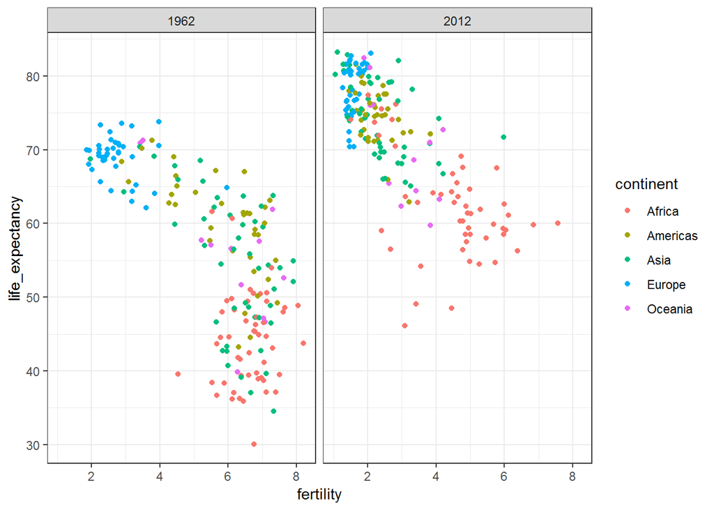

```r
# facet by year only
filter(gapminder, year %in% c(1962, 2012)) %>%
    ggplot(aes(fertility, life_expectancy, col = continent)) +
    geom_point() +
    facet_grid(. ~ year)
```

We simply type facet_grid dot– meaning we’re not using a variable for the rows– tilde year which now tells it make two columns– 1962 and 2012. And here is the plot.

After we split the plot like this, it clearly shows that the majority of countries have moved from the developing world cluster to the Western world one. They went from having large families and short lifespans to having smaller families and longer lifespans. In 2012, the Western versus developing world view no longer makes sense. This is particularly clear when we compare Europe to Asia. Asia includes several countries that have made great improvements in the last 40 to 50 years.

Instead, we might want to have the plots across different rows and columns. For this, we can use the facet_wrap function which permits us to do this. It automatically wraps the series of plots so that most displays has viewable dimensions. So the code looks like this.

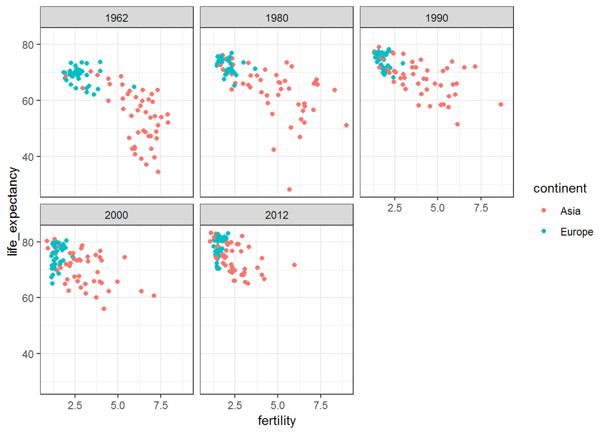

```r
# facet by year, plots wrapped onto multiple rows
years <- c(1962, 1980, 1990, 2000, 2012)
continents <- c("Europe", "Asia")
gapminder %>%
    filter(year %in% years & continent %in% continents) %>%
    ggplot(aes(fertility, life_expectancy, col = continent)) +
    geom_point() +
    facet_wrap(~year)
```

It’s very similar. We’re adding some years. And then at the end, we facet_wrap instead of facet_grid. And now, the plot looks like this.

Now, we’re only showing Asia and Europe, but the function clearly shows us how the Asian countries have made great improvements throughout the years.

Now, note that the default choice for the range of the axes is an important one. When not using facet, this range is determined by the data shown in the plot. When using facet, the range is determined by the data shown in all plots. And therefore, it’s kept fixed across the plots. This makes comparisons across plots much easier. For example, in the plot we just saw, the life expectancy has increased, and the fertility has decreased across most countries.